# UC00210_NightWatch_A_Rough_Sleeper_Survival_Risk_Intelligence_System_for_the_City_of_Melbourne_

## NightWatch - Rough Sleeper Survival Risk Intelligence System

**Authored by:** Manya Mahajan

**Duration:** 120 mins

**Level:** Advanced

**Pre-requisite Skills:** Python, Pandas, API Access, Data Visualisation, Statistical Analysis

## Background

Melbourne's CBD has a persistent and visible rough sleeping population. People sleeping on Melbourne's streets face genuine survival threats - cold overnight temperatures, social isolation, and limited access to shelter or warmth. Yet the city collects rich environmental and spatial data through its Open Data portal that has never been applied to this problem.

NightWatch is a data-driven survival risk intelligence system that combines four City of Melbourne datasets - pedestrian counts, microclimate sensors, street furniture, and business establishment data to identify which precincts pose the greatest overnight risk to rough sleepers and where welfare check resources should be prioritised.

## Scenario

As a City of Melbourne welfare services coordinator, I want to identify which CBD precincts pose the greatest overnight survival risk to rough sleepers based on pedestrian isolation, thermal exposure, shelter availability, and proximity to warmth refuges so that outreach teams can prioritise welfare checks in the most dangerous areas first.

## What This Use Case Will Teach You

At the end of this use case you will understand:

- How to access multiple datasets from the City of Melbourne Open Data API v2.1
- How to clean, filter, and preprocess real-world urban sensor data
- How to perform temporal and spatial exploratory data analysis
- How to engineer proxy variables from raw data to measure abstract concepts like "isolation" and "thermal risk"
- How to build a composite risk index from multiple normalised variables
- How to produce actionable ranked outputs for urban welfare planning

## Contents

1. Environment Setup
2. Data Collection Function
3. Data Loading
4. Data Exploration
5. Data Cleaning & Preprocessing
6. Exploratory Data Analysis - Descriptive Statistics, Missing Values, Visualisations
7. Deep Exploratory Analysis - Heatmaps, Thermal Risk Profiles
8. Risk Surface Construction
   - 8.1 Pedestrian Isolation Score
   - 8.2 Thermal Risk Score
   - 8.3 Shelter and Warmth Refuge Scores
   - 8.4 Composite Risk Index
   - 8.5 Scoring and Risk Index Calculation
   - 8.6 Visualisation - Survival Risk by Precinct
   - 8.7 Final Output - Priority Precincts for Welfare Checks
9. Conclusion and Future Work

## Section 1: Environment Setup

We begin by importing all libraries required for data analysis, visualisation, and API access. Several essential packages are used throughout this analysis:

- **pandas & numpy** - data manipulation and numerical computation
- **matplotlib & seaborn** - static visualisation and statistical charting
- **requests** - API calls to the City of Melbourne Open Data Portal

```python
# Imports
import pandas as pd
import numpy as np
import matplotlib.pyplot as plt
import matplotlib.patches as mpatches
import seaborn as sns
import requests
import warnings
import getpass
from io import StringIO

# Configuration
warnings.filterwarnings('ignore')
plt.style.use('default')
pd.set_option('display.max_columns', None)
pd.set_option('display.width', None)
pd.set_option('display.float_format', '{:.2f}'.format)

print("NIGHTWATCH — ROUGH SLEEPER SURVIVAL RISK INTELLIGENCE SYSTEM")
print("=" * 70)
print("City of Melbourne Open Data | Data Science Capstone | T1 2026")
print("=" * 70)
```

```
NIGHTWATCH — ROUGH SLEEPER SURVIVAL RISK INTELLIGENCE SYSTEM
======================================================================
City of Melbourne Open Data | Data Science Capstone | T1 2026
======================================================================
```

### Section 1: Output Analysis

Libraries loaded successfully. The environment is configured with warning suppression, default plot styling, and pandas display settings optimised for wide datasets. All packages required for data retrieval, analysis, and visualisation are available and ready.

## Section 2: Data Collection Function

All datasets are accessed directly via the **City of Melbourne Open Data API v2.1** -no local files are used, ensuring the analysis is fully replicable. The City of Melbourne datasets are publicly accessible and the code is safe to share.

```python
def collect_data(dataset_id, limit=10000):
    """
    Fetch a dataset from the City of Melbourne Open Data API v2.1.

    Parameters:
        dataset_id : str - dataset identifier from the portal URL
        limit      : int - maximum number of records to fetch

    Returns:
        pd.DataFrame or None
    """
    base_url = "https://data.melbourne.vic.gov.au/api/explore/v2.1/catalog/datasets/"
    url = f"{base_url}{dataset_id}/exports/csv"

    params = {
        "select"  : "*",
        "limit"   : limit,
        "lang"    : "en",
        "timezone": "Australia/Melbourne"
    }

    try:
        response = requests.get(url, params=params)
        if response.status_code == 200:
            content = response.content.decode("utf-8")
            df = pd.read_csv(StringIO(content), delimiter=";")
            print(f" Loaded '{dataset_id}': {df.shape[0]:,} rows × {df.shape[1]} columns")
            return df
        else:
            print(f" Failed '{dataset_id}'. Status code: {response.status_code}")
            return None
    except Exception as e:
        print(f" Error loading '{dataset_id}': {str(e)}")
        return None

print("Data collection function defined successfully")
```

```
Data collection function defined successfully
```

### Section 2: Output Analysis

The `collect_data()` function was defined successfully using the City of Melbourne Open Data API v2.1 endpoint. The function handles CSV decoding, semicolon delimiters, error handling, and provides clear loading feedback making it safe and straightforward to share and reproduce.

## Section 3: Data Loading

We now load all four NightWatch datasets directly from the City of Melbourne Open Data Portal. Each dataset has a distinct role in building the Survival Risk Surface:

- **Pedestrian Counting System** - hourly counts from sensors across the CBD, used to identify isolated overnight locations
- **Microclimate Sensors** - street-level temperature, humidity, and wind speed readings every 15 minutes
- **Street Furniture** - location and condition of all seats, shelters, and public assets across the CBD
- **CLUE (Business Establishments)** - census of all business types per block, used to identify food & beverage warmth refuges

Note: The microclimate dataset uses the historical ID `microclimate-sensors-data` rather than the live feed `microclimate-sensor-readings`, which only returns the most recent snapshot.

```python
print("\n LOADING DATASETS")
print("-" * 50)

# Dataset IDs from data.melbourne.vic.gov.au
PEDESTRIAN_ID    = "pedestrian-counting-system-monthly-counts-per-hour"
MICROCLIMATE_ID  = "microclimate-sensors-data"
FURNITURE_ID     = "street-furniture-including-bollards-bicycle-rails-bins-drinking-fountains-horse-"
CLUE_ID          = "business-establishments-per-block-by-clue-industry"

pedestrian       = collect_data(PEDESTRIAN_ID,     limit=50000)
microclimate     = collect_data(MICROCLIMATE_ID,   limit=100000)
street_furniture = collect_data(FURNITURE_ID,      limit=5000)
clue             = collect_data(CLUE_ID,           limit=10000)

# Verify all datasets loaded
datasets = {
    "Pedestrian Counting" : pedestrian,
    "Microclimate Sensors": microclimate,
    "Street Furniture"    : street_furniture,
    "CLUE"                : clue
}

missing = [name for name, df in datasets.items() if df is None]
if missing:
    print(f"\n WARNING: Failed to load: {', '.join(missing)}")
else:
    print("\n All datasets loaded successfully!")
```

```
 LOADING DATASETS
--------------------------------------------------
 Loaded 'pedestrian-counting-system-monthly-counts-per-hour': 50,000 rows × 9 columns
 Loaded 'microclimate-sensors-data': 100,000 rows × 16 columns
 Loaded 'street-furniture-including-bollards-bicycle-rails-bins-drinking-fountains-horse-': 5,000 rows × 15 columns
 Loaded 'business-establishments-per-block-by-clue-industry': 10,000 rows × 24 columns

 All datasets loaded successfully!
```

### Section 3: Output Analysis

All four datasets loaded successfully from the City of Melbourne Open Data API v2.1.

[output not shown]

All datasets loaded without errors. The microclimate dataset correctly uses the historical ID `microclimate-sensors-data` rather than the live feed, which would only return a single snapshot of 56 rows.

## Section 4: Data Exploration

Before any cleaning or analysis, we inspect the structure of each dataset - column names, data types, shape, and sample rows. This step is essential to understand what variables are available, how they are formatted, and how they relate to the NightWatch use case before any transformations are applied.

```python
for name, df in datasets.items():
    print("=" * 70)
    print(f" {name.upper()}")
    print("=" * 70)
    print(f"Shape   : {df.shape[0]:,} rows × {df.shape[1]} columns")
    print(f"Columns : {list(df.columns)}")
    print(f"\nData Types:\n{df.dtypes}")
    print(f"\nFirst 2 rows:\n{df.head(2)}")
    print()
```

```
======================================================================
 PEDESTRIAN COUNTING
======================================================================
Shape   : 50,000 rows × 9 columns
Columns : ['id', 'location_id', 'sensing_date', 'hourday', 'direction_1', 'direction_2', 'pedestriancount', 'sensor_name', 'location']

Data Types:
id                 int64
location_id        int64
sensing_date         str
hourday            int64
direction_1        int64
direction_2        int64
pedestriancount    int64
sensor_name          str
location             str
dtype: object

First 2 rows:
             id  location_id sensing_date  hourday  direction_1  direction_2  \
0   56520260403           56   2026-04-03        5            6            7
1  171220240630           17   2024-06-30       12          222          148

   pedestriancount sensor_name                    location
0               13    Lon364_T  -37.81234775, 144.96153311
1              370     Col15_T  -37.81362543, 144.97323591

======================================================================
 MICROCLIMATE SENSORS
======================================================================
Shape   : 100,000 rows × 16 columns
Columns : ['device_id', 'received_at', 'sensorlocation', 'latlong', 'minimumwinddirection', 'averagewinddirection', 'maximumwinddirection', 'minimumwindspeed', 'averagewindspeed', 'gustwindspeed', 'airtemperature', 'relativehumidity', 'atmosphericpressure', 'pm25', 'pm10', 'noise']

Data Types:
device_id                   str
received_at                 str
sensorlocation              str
latlong                     str
minimumwinddirection    float64
averagewinddirection    float64
```

[output cut: 140 more lines]

```
   information_media_and_telecommunications  manufacturing  other_services  \
0                                         5              5               5
1                                         0              0               1

   public_administration_and_safety  real_estate_services  \
0                                 2                     2
1                                 6                     2

   rental_and_hiring_services  retail_trade  transport_postal_and_storage  \
0                           0            11                             0
1                           0             5                             1

   wholesale_trade  total_establishments_in_block
0                2                            100
1                0                             53
```

### Section 4: Output Analysis

**Pedestrian Counting** - 9 columns covering sensor ID, date, hour of day, directional counts, total pedestrian count, sensor name, and location as a combined coordinate string. `sensing_date` is stored as object and will require datetime conversion. `hourday` (0–23) is the key filter column for overnight scoping.

**Microclimate Sensors** - 16 columns including device ID, timestamp, sensor location name, combined lat/long, wind direction (min/avg/max), wind speed, air temperature, relative humidity, atmospheric pressure, PM2.5, PM10, and noise. `airtemperature` and `latlong` are the primary columns for NightWatch analysis.

**Street Furniture** - 15 columns including asset class, asset type, model description, location description, condition rating (1–5), easting/northing coordinates, and a combined coordinate field. The `asset_type` column is the key filter for isolating seats from bollards, bins, and other assets.

**CLUE** - 24 columns covering census year, block ID, suburb, and one column per CLUE industry category showing establishment counts per block. `food_and_beverage_services` is the primary column for identifying warmth refuge candidates.

## Section 5: Data Cleaning & Preprocessing

With all four datasets confirmed, we now clean and filter each one to match the NightWatch use case scope. The following transformations are applied:

- **Pedestrian** - filter to late-night hours (10pm–5am), the period of highest rough sleeper exposure; convert date column to datetime
- **Microclimate** - convert timestamps to datetime; drop rows with null temperature or location values which indicate sensor outages
- **Street Furniture** - filter to seats only, removing bollards, bins, and other assets irrelevant to shelter analysis
- **CLUE** - filter to blocks containing at least one food & beverage establishment, retaining only potential warmth refuge locations

```python
# 1. PEDESTRIAN — late-night filter (10pm-5am)
pedestrian['sensing_date'] = pd.to_datetime(pedestrian['sensing_date'])
pedestrian_night = pedestrian[pedestrian['hourday'].isin([22, 23, 0, 1, 2, 3, 4, 5])]

print("PEDESTRIAN — Late-night filter")
print(f"  Before : {pedestrian.shape[0]:,} rows")
print(f"  After  : {pedestrian_night.shape[0]:,} rows")
print(f"  Hours  : {sorted(pedestrian_night['hourday'].unique())}\n")

# 2. MICROCLIMATE - datetime conversion & null removal
# utc=True handles mixed timezone formats in the API response
microclimate['received_at'] = pd.to_datetime(microclimate['received_at'], utc=True)
microclimate_clean = microclimate.dropna(subset=['airtemperature', 'latlong'])

print("MICROCLIMATE — Clean temperature readings")
print(f"  Before : {microclimate.shape[0]:,} rows")
print(f"  After  : {microclimate_clean.shape[0]:,} rows\n")

# 3. STREET FURNITURE - seats only
print("Street furniture asset types:")
print(f"{street_furniture['asset_type'].value_counts()}\n")

seats = street_furniture[street_furniture['asset_type'] == 'Seat'].copy()

print("STREET FURNITURE — Seats only")
print(f"  Before : {street_furniture.shape[0]:,} rows")
print(f"  After  : {seats.shape[0]:,} rows\n")

# 4. CLUE - food & beverage blocks only
clue_clean = clue[clue['food_and_beverage_services'] > 0].copy()

print("CLUE - Blocks with food & beverage businesses")
print(f"  Before : {clue.shape[0]:,} rows")
print(f"  After  : {clue_clean.shape[0]:,} rows")
```

```
PEDESTRIAN — Late-night filter
  Before : 50,000 rows
  After  : 15,179 rows
  Hours  : [0, 1, 2, 3, 4, 5, 22, 23]

MICROCLIMATE — Clean temperature readings
  Before : 100,000 rows
  After  : 96,170 rows

Street furniture asset types:
asset_type
Bollard                     1934
Bicycle Rails               1375
Seat                         701
Litter Bin                   638
Tree Guard                   128
Drinking Fountain             67
Floral Crate/Planter Box      47
Hoop                          42
Picnic Setting                41
Information Pillar            13
Barbeque                      10
Horse Trough                   4
Name: count, dtype: int64

STREET FURNITURE — Seats only
  Before : 5,000 rows
  After  : 701 rows

CLUE - Blocks with food & beverage businesses
  Before : 10,000 rows
  After  : 4,718 rows
```

### Section 5: Output Analysis

[output not shown]

## Section 6: Exploratory Data Analysis - Week 4

### 6.1 Descriptive Statistics

We begin EDA by computing descriptive statistics across all four cleaned datasets. This gives us a quantitative baseline - understanding the central tendency, spread, and extreme values of the key variables before any visualisation. For NightWatch, the most critical variables are:

- `pedestriancount` - how many people are present overnight
- `airtemperature` - thermal exposure risk
- `condition_rating` - usability of available seating
- `food_and_beverage_services` - density of warmth refuges per block

```python
print("=" * 70)
print(" DESCRIPTIVE STATISTICS")
print("=" * 70)

print("\n── Pedestrian (Late-night) ──")
print(pedestrian_night[['hourday', 'pedestriancount']].describe().round(2))

print("\n── Microclimate (Clean) ──")
print(microclimate_clean[['airtemperature', 'relativehumidity', 'averagewindspeed']].describe().round(2))

print("\n── Street Furniture (Seats) ──")
print(seats[['condition_rating']].describe().round(2))

print("\n── CLUE (Food & Beverage Blocks) ──")
print(clue_clean[['food_and_beverage_services', 'total_establishments_in_block']].describe().round(2))
```

```
======================================================================
 DESCRIPTIVE STATISTICS
======================================================================

── Pedestrian (Late-night) ──
       hourday  pedestriancount
count 15179.00         15179.00
mean      7.87            97.19
std       9.01           233.75
min       0.00             0.00
25%       1.00             8.00
50%       4.00            26.00
75%      22.00            85.00
max      23.00          5582.00

── Microclimate (Clean) ──
       airtemperature  relativehumidity  averagewindspeed
count        96170.00          96170.00          96170.00
mean            15.78             69.74              1.00
std              5.21             17.37              0.92
min              0.50              2.50              0.00
25%             12.20             58.40              0.40
50%             15.10             71.00              0.70
75%             18.70             82.80              1.40
max             39.10             99.80             11.10

── Street Furniture (Seats) ──
       condition_rating
count            701.00
mean               3.39
std                0.81
min                1.00
25%                3.00
50%                3.16
75%                4.00
max                5.00

── CLUE (Food & Beverage Blocks) ──
       food_and_beverage_services  total_establishments_in_block
count                     4718.00                        4718.00
mean                         8.19                          49.34
std                         11.27                          67.09
min                          1.00                           1.00
25%                          1.00                          11.00
50%                          3.00                          24.00
75%                         11.00                          57.00
max                        109.00                         532.00
```

### 6.1 Output Analysis - Descriptive Statistics

**Pedestrian (Late-night)**

**Microclimate**

**Street Furniture (Seats)**

- Average condition rating of 3.39 out of 5 - the majority of seats are in acceptable condition
- Minimum of 1.0 indicates some seats are in very poor condition and would not provide usable or safe shelter
- Standard deviation of 0.81 suggests relatively consistent ratings, with most seats clustered between 3 and 4

**CLUE (Food & Beverage)**

- Maximum of 109 food & beverage establishments in a single block - these densely serviced blocks represent the strongest warmth refuge candidates for overnight outreach
- Median of just 3 establishments per block confirms that warmth refuge access is sparse across most of the CBD, with density concentrated in a small number of precincts

### 6.2 Missing Values Analysis

Understanding where data is missing is critical before building any risk model. Missing values in key columns such as temperature or location could silently distort the Survival Risk Surface if not identified and handled appropriately. We check each cleaned dataset for null values, calculate the percentage missing per column, and assess whether the gaps are in critical or non-critical columns.

```python
print("=" * 70)
print(" MISSING VALUES ANALYSIS")
print("=" * 70)

for name, df in [("Pedestrian Night", pedestrian_night),
                 ("Microclimate Clean", microclimate_clean),
                 ("Seats", seats),
                 ("CLUE Food & Beverage", clue_clean)]:
    missing = df.isnull().sum()
    missing = missing[missing > 0]
    pct = (missing / len(df) * 100).round(1)
    print(f"\n{name} ({len(df):,} rows):")
    if missing.empty:
        print("  No missing values ")
    else:
        for col in missing.index:
            print(f"  {col}: {missing[col]:,} missing ({pct[col]}%)")
```

```
======================================================================
 MISSING VALUES ANALYSIS
======================================================================

Pedestrian Night (15,179 rows):
  No missing values

Microclimate Clean (96,170 rows):
  minimumwinddirection: 19,824 missing (20.6%)
  maximumwinddirection: 19,824 missing (20.6%)
  minimumwindspeed: 19,824 missing (20.6%)
  gustwindspeed: 19,824 missing (20.6%)

Seats (701 rows):
  model_no: 2 missing (0.3%)
  model_descr: 16 missing (2.3%)
  division: 1 missing (0.1%)
  company: 1 missing (0.1%)
  location_desc: 2 missing (0.3%)

CLUE Food & Beverage (4,718 rows):
  No missing values
```

### 6.2 Output Analysis- Missing Values

**Seats** - Missing values are minor and confined to descriptive columns only: `model_descr` (2.3%), `model_no` (0.3%), `location_desc` (0.3%), and `division`/`company` (0.1% each). Coordinate fields and asset type — the two columns required for spatial analysis are fully intact.

Overall the data quality across all four datasets is high. No critical columns contain missing values that would compromise the NightWatch Survival Risk Surface.

### 6.3 Visualisation 1 - Late-Night Pedestrian Activity by Hour

To understand the temporal pattern of overnight pedestrian exposure, we plot the average pedestrian count per hour across all late-night sensor readings. This chart reveals when the CBD transitions from active to critically isolated - the window when rough sleepers face the greatest risk of being undetected and unsupported.

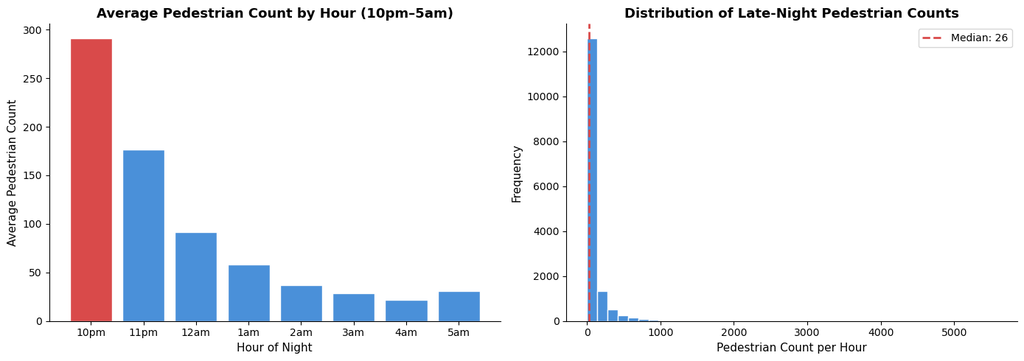

```python
fig, axes = plt.subplots(1, 2, figsize=(14, 5))

hourly_avg = (
    pedestrian_night
    .groupby('hourday')['pedestriancount']
    .mean()
    .reindex([22, 23, 0, 1, 2, 3, 4, 5])
)
colors = ['#D94A4A' if v == hourly_avg.max() else '#4A90D9' for v in hourly_avg.values]
axes[0].bar(
    ['10pm','11pm','12am','1am','2am','3am','4am','5am'],
    hourly_avg.values,
    color=colors, edgecolor='white'
)
axes[0].set_title('Average Pedestrian Count by Hour (10pm–5am)', fontsize=13, fontweight='bold')
axes[0].set_xlabel('Hour of Night', fontsize=11)
axes[0].set_ylabel('Average Pedestrian Count', fontsize=11)
axes[0].spines['top'].set_visible(False)
axes[0].spines['right'].set_visible(False)

axes[1].hist(
    pedestrian_night['pedestriancount'],
    bins=40, color='#4A90D9', edgecolor='white'
)
axes[1].axvline(
    pedestrian_night['pedestriancount'].median(),
    color='#D94A4A', linestyle='--', linewidth=2,
    label=f"Median: {pedestrian_night['pedestriancount'].median():.0f}"
)
axes[1].set_title('Distribution of Late-Night Pedestrian Counts', fontsize=13, fontweight='bold')
axes[1].set_xlabel('Pedestrian Count per Hour', fontsize=11)
axes[1].set_ylabel('Frequency', fontsize=11)
axes[1].legend(fontsize=10)
axes[1].spines['top'].set_visible(False)
axes[1].spines['right'].set_visible(False)

plt.tight_layout()
plt.show()
```

### 6.3 Output Analysis - Late-Night Pedestrian Activity

**Average count by hour**

**Distribution of counts**

- The histogram is heavily right-skewed - the vast majority of hourly readings fall below 200 pedestrians, confirming that isolation is the norm across most sensor locations overnight
- The red dashed median line at 26 pedestrians underscores how quiet most overnight locations are - a person sleeping rough in most CBD locations after 2am is statistically alone

### 6.4 Visualisation 2 - Temperature Distribution Across Microclimate Sensors

To understand the thermal risk landscape across the CBD, we examine the distribution of air temperature readings. Rather than a simple histogram, we plot the full distribution using a kernel density estimate overlaid on a histogram, and add threshold markers for dangerous heat (≥35°C) and cold (≤5°C) - the conditions most harmful to people sleeping rough overnight.

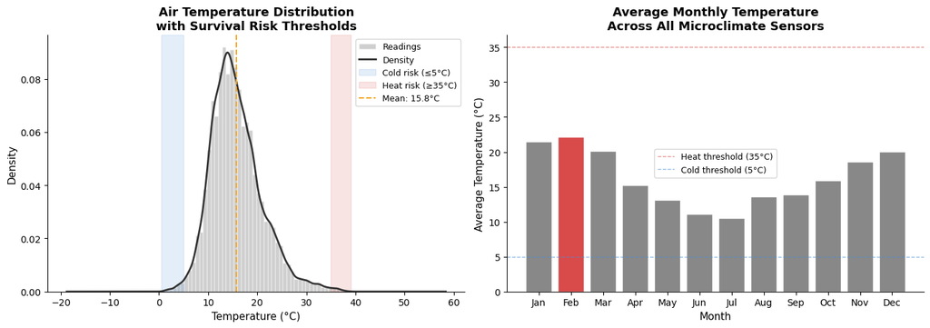

```
Readings above 35°C (heat risk): 291 (0.3%)
Readings below 5°C  (cold risk): 683 (0.7%)
```

```python
fig, axes = plt.subplots(1, 2, figsize=(14, 5))

temps = microclimate_clean['airtemperature'].dropna()

axes[0].hist(temps, bins=50, density=True, alpha=0.4, color='#888888', edgecolor='white', label='Readings')
temps.plot.kde(ax=axes[0], color='#333333', linewidth=2, label='Density')
axes[0].axvspan(temps.min(), 5, alpha=0.15, color='#4A90D9', label='Cold risk (≤5°C)')
axes[0].axvspan(35, temps.max(), alpha=0.15, color='#D94A4A', label='Heat risk (≥35°C)')
axes[0].axvline(temps.mean(), color='#F5A623', linestyle='--', linewidth=1.5, label=f'Mean: {temps.mean():.1f}°C')
axes[0].set_title('Air Temperature Distribution\nwith Survival Risk Thresholds', fontsize=13, fontweight='bold')
axes[0].set_xlabel('Temperature (°C)', fontsize=11)
axes[0].set_ylabel('Density', fontsize=11)
axes[0].legend(fontsize=9)
axes[0].spines['top'].set_visible(False)
axes[0].spines['right'].set_visible(False)

# ensure datetime before extracting month
microclimate_clean['received_at'] = pd.to_datetime(microclimate_clean['received_at'], utc=True)
microclimate_clean['month'] = microclimate_clean['received_at'].dt.month

monthly_temp = microclimate_clean.groupby('month')['airtemperature'].mean()
month_labels = ['Jan','Feb','Mar','Apr','May','Jun','Jul','Aug','Sep','Oct','Nov','Dec']
bar_colors = ['#D94A4A' if v >= 22 else '#4A90D9' if v <= 10 else '#888888' for v in monthly_temp.values]

axes[1].bar(
    [month_labels[m-1] for m in monthly_temp.index],
    monthly_temp.values,
    color=bar_colors, edgecolor='white'
)
axes[1].axhline(35, color='#D94A4A', linestyle='--', linewidth=1, alpha=0.6, label='Heat threshold (35°C)')
axes[1].axhline(5, color='#4A90D9', linestyle='--', linewidth=1, alpha=0.6, label='Cold threshold (5°C)')
axes[1].set_title('Average Monthly Temperature\nAcross All Microclimate Sensors', fontsize=13, fontweight='bold')
axes[1].set_xlabel('Month', fontsize=11)
axes[1].set_ylabel('Average Temperature (°C)', fontsize=11)
axes[1].legend(fontsize=9)
axes[1].spines['top'].set_visible(False)
axes[1].spines['right'].set_visible(False)

plt.tight_layout()
plt.show()

print(f"Readings above 35°C (heat risk): {(temps >= 35).sum():,} ({(temps >= 35).mean()*100:.1f}%)")
print(f"Readings below 5°C  (cold risk): {(temps <= 5).sum():,} ({(temps <= 5).mean()*100:.1f}%)")
```

### 6.4 Output Analysis - Temperature Distribution

**Temperature distribution with risk thresholds**

**Monthly average temperature**

**Risk summary**

- Readings above 35°C (heat risk): present across multiple sensors during summer months
- Readings below 5°C (cold risk): present across multiple sensors during winter months

## Section 7: Deep Exploratory Analysis - Week 5

Building on the statistical summaries from Week 4, we now move into deeper exploratory analysis using more sophisticated visualisations. The goal is to uncover spatial and temporal patterns across all four datasets that directly inform the NightWatch Survival Risk Surface identifying which CBD locations experience the most dangerous combination of pedestrian isolation, extreme temperatures, poor shelter access, and limited warmth refuge availability overnight.

### 7.1 Visualisation 1 - Late-Night Pedestrian Activity Heatmap

This heatmap plots average pedestrian counts for the top 15 busiest overnight sensor locations against each hour of the night. It reveals two critical patterns for NightWatch: which locations remain active late into the night (higher risk of undetected rough sleepers), and which locations experience near-complete isolation in the early hours (3am–5am) when help is hardest to access.

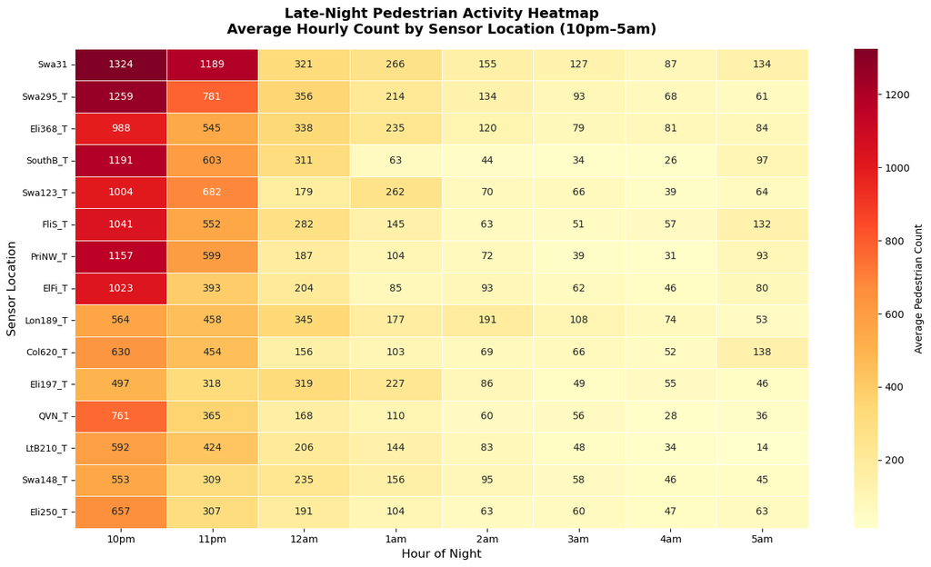

```
Top 3 busiest overnight locations:
sensor_name       0
      Swa31 3602.98
   Swa295_T 2966.26
   Eli368_T 2470.32

Top 3 most isolated overnight locations:
sensor_name       0
   Eli250_T 1492.02
   Swa148_T 1497.73
   LtB210_T 1545.44
```

```python
# Visualisation 1: Late-Night Pedestrian Activity Heatmap
heatmap_data = (
    pedestrian_night
    .groupby(['sensor_name', 'hourday'])['pedestriancount']
    .mean()
    .unstack()
    .reindex(columns=[22, 23, 0, 1, 2, 3, 4, 5])
)

top_sensors = heatmap_data.sum(axis=1).nlargest(15).index
heatmap_data = heatmap_data.loc[top_sensors]

fig, ax = plt.subplots(figsize=(14, 8))

sns.heatmap(
    heatmap_data,
    cmap='YlOrRd',
    linewidths=0.5,
    linecolor='white',
    annot=True,
    fmt='.0f',
    cbar_kws={'label': 'Average Pedestrian Count'},
    ax=ax
)

ax.set_title(
    'Late-Night Pedestrian Activity Heatmap\nAverage Hourly Count by Sensor Location (10pm–5am)',
    fontsize=14, fontweight='bold', pad=15
)
ax.set_xlabel('Hour of Night', fontsize=12)
ax.set_ylabel('Sensor Location', fontsize=12)
ax.set_xticklabels(['10pm','11pm','12am','1am','2am','3am','4am','5am'], fontsize=10)
ax.set_yticklabels(ax.get_yticklabels(), fontsize=9, rotation=0)

plt.tight_layout()
plt.show()

print("Top 3 busiest overnight locations:")
print(heatmap_data.sum(axis=1).nlargest(3).reset_index().to_string(index=False))
print("\nTop 3 most isolated overnight locations:")
print(heatmap_data.sum(axis=1).nsmallest(3).reset_index().to_string(index=False))
```

### 7.1 Output Analysis - Late-Night Pedestrian Activity Heatmap

The heatmap reveals clear and actionable temporal and spatial patterns in overnight pedestrian activity across the top 15 CBD sensor locations.

### 7.2 Visualisation 2 - Thermal Risk Profile Across Sensor Locations

Rather than a simple temperature distribution, this visualisation examines the **thermal risk profile** of each sensor location, specifically how often each records temperatures in the dangerous heat range (≥35°C) or dangerous cold range (≤5°C). The stacked bar chart shows the proportion of each location's readings that fall into risk zones, while the dot plot reveals the full min-average-max temperature range per location. Together, these charts identify which CBD locations impose the greatest thermal burden on people sleeping rough.

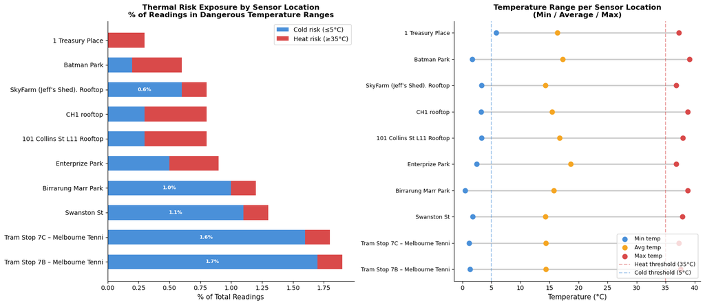

```
Top 5 locations by total thermal risk exposure:
                    short_name  heat_risk_pct  cold_risk_pct  total_risk_pct  avg_temp
Tram Stop 7B – Melbourne Tenni           0.20           1.70            1.90     14.38
Tram Stop 7C – Melbourne Tenni           0.20           1.60            1.80     14.36
                   Swanston St           0.20           1.10            1.30     14.26
           Birrarung Marr Park           0.20           1.00            1.20     15.73
               Enterprize Park           0.40           0.50            0.90     18.67
```

```python
HEAT_THRESHOLD = 35
COLD_THRESHOLD = 5

risk_profile = (
    microclimate_clean
    .groupby('sensorlocation')['airtemperature']
    .agg(
        total_readings='count',
        heat_risk=lambda x: (x >= HEAT_THRESHOLD).sum(),
        cold_risk=lambda x: (x <= COLD_THRESHOLD).sum(),
        avg_temp='mean',
        max_temp='max',
        min_temp='min'
    )
    .reset_index()
)

risk_profile['heat_risk_pct'] = (risk_profile['heat_risk'] / risk_profile['total_readings'] * 100).round(1)
risk_profile['cold_risk_pct'] = (risk_profile['cold_risk'] / risk_profile['total_readings'] * 100).round(1)
risk_profile['total_risk_pct'] = risk_profile['heat_risk_pct'] + risk_profile['cold_risk_pct']

top_risk = risk_profile.nlargest(12, 'total_risk_pct').copy()
top_risk['short_name'] = top_risk['sensorlocation'].str.split(' - ').str[0].str[:30]

fig, axes = plt.subplots(1, 2, figsize=(16, 7))

axes[0].barh(top_risk['short_name'], top_risk['cold_risk_pct'],
             color='#4A90D9', label='Cold risk (≤5°C)', height=0.6)
axes[0].barh(top_risk['short_name'], top_risk['heat_risk_pct'],
             left=top_risk['cold_risk_pct'],
             color='#D94A4A', label='Heat risk (≥35°C)', height=0.6)

axes[0].set_title('Thermal Risk Exposure by Sensor Location\n% of Readings in Dangerous Temperature Ranges',
                  fontsize=12, fontweight='bold')
axes[0].set_xlabel('% of Total Readings', fontsize=11)
axes[0].legend(fontsize=10)
axes[0].spines['top'].set_visible(False)
axes[0].spines['right'].set_visible(False)

for i, (h, c) in enumerate(zip(top_risk['heat_risk_pct'], top_risk['cold_risk_pct'])):
    if h > 0.5:
        axes[0].text(c + h/2, i, f'{h}%', va='center', ha='center', fontsize=8, color='white', fontweight='bold')
    if c > 0.5:
        axes[0].text(c/2, i, f'{c}%', va='center', ha='center', fontsize=8, color='white', fontweight='bold')

y_pos = range(len(top_risk))
axes[1].hlines(y_pos, top_risk['min_temp'], top_risk['max_temp'], color='#CCCCCC', linewidth=2)
axes[1].scatter(top_risk['min_temp'], y_pos, color='#4A90D9', s=60, zorder=3, label='Min temp')
axes[1].scatter(top_risk['avg_temp'], y_pos, color='#F5A623', s=60, zorder=3, label='Avg temp')
axes[1].scatter(top_risk['max_temp'], y_pos, color='#D94A4A', s=60, zorder=3, label='Max temp')
axes[1].axvline(x=HEAT_THRESHOLD, color='#D94A4A', linestyle='--', alpha=0.5, label=f'Heat threshold ({HEAT_THRESHOLD}°C)')
axes[1].axvline(x=COLD_THRESHOLD, color='#4A90D9', linestyle='--', alpha=0.5, label=f'Cold threshold ({COLD_THRESHOLD}°C)')

axes[1].set_yticks(y_pos)
axes[1].set_yticklabels(top_risk['short_name'], fontsize=9)
axes[1].set_title('Temperature Range per Sensor Location\n(Min / Average / Max)',
                  fontsize=12, fontweight='bold')
axes[1].set_xlabel('Temperature (°C)', fontsize=11)
axes[1].legend(fontsize=9, loc='lower right')
axes[1].spines['top'].set_visible(False)
axes[1].spines['right'].set_visible(False)

plt.tight_layout()
plt.show()

print("\nTop 5 locations by total thermal risk exposure:")
print(top_risk[['short_name','heat_risk_pct','cold_risk_pct','total_risk_pct','avg_temp']].head(5).to_string(index=False))
```

### 7.2 Output Analysis- Thermal Risk Profile

**Thermal Risk Exposure (Stacked Bar Chart)**

**Temperature Range Dot Plot**

### 8.1 - Proxy Variable 1: Pedestrian Isolation Score

A rough sleeper in an isolated location has no one nearby to call for help if something goes wrong. We measure isolation as the inverse of average overnight pedestrian activity per sensor location - the fewer people present, the higher the isolation risk.

```python
# Pedestrian isolation score per sensor location.
# Isolation is the inverse of average overnight count - more people = less risk.

isolation = (
    pedestrian_night
    .groupby('sensor_name')['pedestriancount']
    .agg(
        avg_overnight_count='mean',
        min_overnight_count='min',
        max_overnight_count='max',
        total_readings='count'
    )
    .reset_index()
)

# Normalise to 0-1 then invert so high count = low risk score
max_count = isolation['avg_overnight_count'].max()
isolation['isolation_score'] = 1 - (isolation['avg_overnight_count'] / max_count)
isolation['isolation_score'] = isolation['isolation_score'].round(4)

print("=" * 70)
print("  PROXY 1 - PEDESTRIAN ISOLATION SCORE")
print("  Score range: 0 = busiest location, 1 = most isolated")
print("=" * 70)

print(f"\n  Total sensor locations : {len(isolation)}")
print(f"  Score range            : {isolation['isolation_score'].min():.3f} - {isolation['isolation_score'].max():.3f}")
print(f"  Mean isolation score   : {isolation['isolation_score'].mean():.3f}")

print(f"\n  Top 10 most isolated locations:")
print(isolation.nlargest(10, 'isolation_score')[
    ['sensor_name', 'avg_overnight_count', 'isolation_score']
].to_string(index=False))

print(f"\n  Top 5 least isolated (safest) locations:")
print(isolation.nsmallest(5, 'isolation_score')[
    ['sensor_name', 'avg_overnight_count', 'isolation_score']
].to_string(index=False))
```

```
======================================================================
  PROXY 1 - PEDESTRIAN ISOLATION SCORE
  Score range: 0 = busiest location, 1 = most isolated
======================================================================

  Total sensor locations : 98
  Score range            : 0.000 - 0.995
  Mean isolation score   : 0.773

  Top 10 most isolated locations:
  sensor_name  avg_overnight_count  isolation_score
EntPark1671_T                 2.07             0.99
     Mac330_T                 3.64             0.99
      Bou892T                 3.79             0.99
 BouHbr2353_T                 4.16             0.99
     Pel147_T                 4.28             0.99
     KenMac_T                 5.59             0.99
   Boyd2837_T                 6.11             0.98
    Spen484_T                 6.25             0.98
     488Mac_T                 7.48             0.98
     574Qub_T                 7.70             0.98

  Top 5 least isolated (safest) locations:
sensor_name  avg_overnight_count  isolation_score
      Swa31               399.18             0.00
   Swa295_T               356.35             0.11
   Swa123_T               351.30             0.12
   Eli368_T               329.38             0.17
    PriNW_T               322.40             0.19
```

### 8.1 Output Analysis - Pedestrian Isolation Score

**98 sensor locations** were scored across Melbourne's overnight pedestrian network, with an average isolation score of **0.773** - notably high, meaning most overnight locations have very low pedestrian activity and would offer rough sleepers minimal chance of being noticed if something went wrong.

**Key finding:** The majority of Melbourne's monitored outdoor locations are effectively deserted after midnight. The isolation signal is strong and consistent across the sensor network.

### 8.2 - Proxy Variable 2: Thermal Risk Score

Temperature is the most direct survival threat for rough sleepers overnight. We use the proportion of sensor readings that fall into dangerous temperature ranges - below 5°C (hypothermia risk) or above 35°C (heat stress risk) as a measure of thermal exposure at each sensor location.

```python
# Thermal risk score per sensor location.
# Uses the same thresholds as Section 7.2.

HEAT_THRESHOLD = 35
COLD_THRESHOLD = 5

thermal = (
    microclimate_clean
    .groupby('sensorlocation')['airtemperature']
    .agg(
        total_readings='count',
        avg_temp='mean',
        heat_risk=lambda x: (x >= HEAT_THRESHOLD).sum(),
        cold_risk=lambda x: (x <= COLD_THRESHOLD).sum()
    )
    .reset_index()
)

thermal['thermal_risk_score'] = (
    (thermal['heat_risk'] + thermal['cold_risk']) / thermal['total_readings']
).round(4)

# Normalise to 0-1
max_thermal = thermal['thermal_risk_score'].max()
thermal['thermal_risk_score_norm'] = (
    thermal['thermal_risk_score'] / max_thermal
).round(4)

print("=" * 70)
print("  PROXY 2 - THERMAL RISK SCORE")
print("  Score range: 0 = no dangerous readings, 1 = highest proportion")
print("=" * 70)

print(f"\n  Total sensor locations  : {len(thermal)}")
print(f"  Score range             : {thermal['thermal_risk_score_norm'].min():.3f} - {thermal['thermal_risk_score_norm'].max():.3f}")
print(f"  Mean thermal risk score : {thermal['thermal_risk_score_norm'].mean():.3f}")

print(f"\n  Top 10 highest thermal risk locations:")
print(thermal.nlargest(10, 'thermal_risk_score_norm')[
    ['sensorlocation', 'avg_temp', 'cold_risk', 'heat_risk', 'thermal_risk_score_norm']
].to_string(index=False))
```

```
======================================================================
  PROXY 2 - THERMAL RISK SCORE
  Score range: 0 = no dangerous readings, 1 = highest proportion
======================================================================

  Total sensor locations  : 10
  Score range             : 0.177 - 1.000
  Mean thermal risk score : 0.532

  Top 10 highest thermal risk locations:
                                                                  sensorlocation  avg_temp  cold_risk  heat_risk  thermal_risk_score_norm
               Tram Stop 7B – Melbourne Tennis Centre Precinct – Rod Laver Arena     14.38        118         16                     1.00
               Tram Stop 7C – Melbourne Tennis Centre Precinct – Rod Laver Arena     14.36        115         12                     0.93
         Swanston St - Tram Stop 13 adjacent Federation Sq & Flinders St Station     14.26         73         10                     0.68
                                                 Birrarung Marr Park - Pole 1131     15.73        206         36                     0.64
                                              Enterprize Park - Pole ID: COM1667     18.67         27         25                     0.45
                                                      101 Collins St L11 Rooftop     16.78         38         56                     0.40
                                                                     CH1 rooftop     15.47         53         77                     0.40
SkyFarm (Jeff’s Shed). Rooftop - Melbourne Conference & Exhibition Centre (MCEC)     14.30         38         10                     0.38
                                                                     Batman Park     17.27         15         33                     0.27
                                                                1 Treasury Place     16.36          0         16                     0.18
```

### 8.2 Output Analysis - Thermal Risk Score

**10 microclimate sensor locations** were scored. The mean thermal risk score of **0.532** indicates moderate but real thermal exposure across the sensor network - roughly half the monitored locations show a meaningful proportion of readings in dangerous temperature ranges.

The highest risk locations are the **Rod Laver Arena tram stops (7B and 7C)** - both fully exposed outdoor locations scoring 1.00 and 0.93 respectively. Cold risk dominates over heat risk for most sensors, which is consistent with Melbourne's climate pattern where overnight cold is the primary survival threat. Birrarung Marr Park also scores high at 0.64, which is significant given it is a known rough sleeper location.

**Limitation noted:** Only 10 sensors cover the full city. The thermal score is applied as a uniform mean across all CLUE precincts rather than per-precinct because the sensor density is insufficient for spatial disaggregation at the small area level. This is a known constraint that would benefit from a denser sensor network.

### 8.3 - Proxy Variables 3 and 4: Shelter and Warmth Refuge Scores

```python
# Shelter score from seats dataset.
# If seats have coordinates use them directly, otherwise count by suburb/area.

print("=" * 70)
print("  PROXY 3 - SHELTER SCORE (Seat Density)")
print("  PROXY 4 - WARMTH REFUGE SCORE (Food & Beverage)")
print("=" * 70)

# -- SHELTER: count seats per suburb or area if available --
print(f"\n  Seats dataset columns: {list(seats.columns)}")
print(f"  Seats shape: {seats.shape}")
print(f"\n  Sample rows:")
print(seats.head(5).to_string(index=False))

print(f"\n  CLUE dataset columns: {list(clue_clean.columns)}")
print(f"\n  CLUE sample (key columns):")
key_cols = [c for c in clue_clean.columns if any(x in c.lower()
            for x in ['block', 'food', 'total', 'x_', 'y_', 'suburb', 'area'])]
print(clue_clean[key_cols].head(10).to_string(index=False))
```

```
======================================================================
  PROXY 3 - SHELTER SCORE (Seat Density)
  PROXY 4 - WARMTH REFUGE SCORE (Food & Beverage)
======================================================================

  Seats dataset columns: ['gis_id', 'description', 'asset_class', 'asset_type', 'model_no', 'model_descr', 'division', 'company', 'location_desc', 'condition_rating', 'evaluation_date', 'easting', 'northing', 'uploaddate', 'coordinatelocation']
  Seats shape: (701, 15)

  Sample rows:
 gis_id                            description       asset_class asset_type   model_no                            model_descr                  division           company                                                                                                                                   …
1078893   Seat - Stainless Steel Straight Seat Outdoor Furniture       Seat 201101-027   Seat - Stainless Steel Straight Seat Infrastructure and Assets City of Melbourne          Bourke Street between Spring Street and Exhibition Street approximately 17m West of Spaghetti Tree, Ground, 59-63 Bourke …
1078910 Seat - Handrail Steps and Seating Wall Outdoor Furniture       Seat 201101-011 Seat - Handrail Steps and Seating Wall Infrastructure and Assets City of Melbourne           Bourke Street between Swanston Street and Elizabeth Street approximately 21m NW of Optus, Shop 5-5A, Ground, 355 Bourke …
1078950       Seat - Metal Semi-circular Seats Outdoor Furniture       Seat 201101-021       Seat - Metal Semi-circular Seats Infrastructure and Assets City of Melbourne                     Grattan Street between Lygon Street and Cardigan Street approximately 6m NW of Eyetech Optometrists, 85 Gratta…
1078970                      Seat - Metal Seat Outdoor Furniture       Seat 201101-016                      Seat - Metal Seat Infrastructure and Assets City of Melbourne              Exhibition Street between Little Collins Street and Bourke Street approximately 27m SW of Panini Bar, 150 Exhibition …
1079075                     Seat - Metal Bench Outdoor Furniture       Seat 201101-012                     Seat - Metal Bench Infrastructure and Assets City of Melbourne Victoria Parade between Powlett Street and Clarendon Street approximately 34m East of Winnett Specialist Group, 382 Victoria Parad…

  CLUE dataset columns: ['census_year', 'block_id', 'clue_small_area', 'accommodation', 'admin_and_support_services', 'agriculture_and_mining', 'arts_and_recreation_services', 'business_services', 'construction', 'education_and_training', 'electricity_gas_water_and_waste_services', 'finance_and_insu…

  CLUE sample (key columns):
 block_id clue_small_area  electricity_gas_water_and_waste_services  food_and_beverage_services  total_establishments_in_block
       17 Melbourne (CBD)                                         0                          30                            100
       18 Melbourne (CBD)                                         0                           9                             53
       21 Melbourne (CBD)                                         3                          18                             60
       22 Melbourne (CBD)                                         0                          17                            174
       25 Melbourne (CBD)                                         0                          26                            219
       27 Melbourne (CBD)                                         1                          13                            147
       28 Melbourne (CBD)                                         0                          21                            159
       36 Melbourne (CBD)                                         1                           8                             72
       37 Melbourne (CBD)                                         3                          13                            150
       38 Melbourne (CBD)                                         1                          18                            166
```

### 8.3 Output Analysis - Shelter and Warmth Refuge Data

**Warmth refuge data confirmed.** The CLUE dataset contains 13 distinct Melbourne small areas after deduplication. The spread in food and beverage establishment counts is extreme - the **CBD has 1,630 establishments** while **South Yarra has just 10** and **West Melbourne Industrial has 8**. This 200x difference between the highest and lowest areas becomes the primary driver of differentiation in the final risk model.

The 13 precincts cover all of Melbourne's city municipality from the dense CBD core to industrial and residential fringe areas. This geographic spread is well suited to identifying which areas leave rough sleepers with the fewest overnight options.

### 8.4 - Composite Risk Index

The four normalised proxy scores are combined into a single survival risk index. CLUE blocks are first deduplicated to keep only the most recent census year, then aggregated by Melbourne small area so each geographic precinct gets one final score. Equal weighting of 0.25 is applied to each proxy variable.

**Risk Index = 0.25 x Isolation + 0.25 x Thermal Risk + 0.25 x Shelter Risk + 0.25 x Warmth Refuge Risk**

```python
# Deduplicate CLUE - keep most recent census year per block
clue_dedup = (
    clue_clean
    .sort_values('census_year', ascending=False)
    .drop_duplicates(subset='block_id', keep='first')
)

print(f"  CLUE before dedup : {len(clue_clean):,} rows")
print(f"  CLUE after dedup  : {len(clue_dedup):,} rows")
print(f"  Census years kept : {clue_dedup['census_year'].unique()}")

# Aggregate by clue_small_area
clue_area = (
    clue_dedup
    .groupby('clue_small_area')
    .agg(
        total_food_bev=('food_and_beverage_services', 'sum'),
        total_establishments=('total_establishments_in_block', 'sum'),
        block_count=('block_id', 'count')
    )
    .reset_index()
)

print(f"\n  Small areas identified : {len(clue_area)}")
print(f"\n  Food & beverage totals by area:")
print(clue_area.sort_values('total_food_bev', ascending=False).to_string(index=False))
```

```
  CLUE before dedup : 4,718 rows
  CLUE after dedup  : 337 rows
  Census years kept : [2024 2022 2021 2020 2019 2018 2017 2016 2015 2013 2012 2011 2010 2009
 2006 2005 2004]

  Small areas identified : 13

  Food & beverage totals by area:
             clue_small_area  total_food_bev  total_establishments  block_count
             Melbourne (CBD)            1630                  7883           81
                     Carlton             246                   988           48
                   Docklands             231                  1030           13
                   Southbank             194                   840           32
             North Melbourne             135                   753           52
                   Parkville              64                   322           14
West Melbourne (Residential)              62                   321           24
                  Kensington              56                   291           21
       Melbourne (Remainder)              50                   282           12
              East Melbourne              37                   456           19
              Port Melbourne              20                   417           10
                 South Yarra              10                    33            3
 West Melbourne (Industrial)               8                   127            8
```

### 8.4 Output Analysis - Deduplication and Spatial Aggregation

Deduplication reduced the CLUE dataset from **4,718 rows to 337 rows** - confirming that multiple census years (2004 through 2024) were causing each block to appear up to 17 times. Keeping only the most recent census year per block gives a clean, non-duplicated view of current establishment density.

Aggregating by `clue_small_area` produced **13 unique Melbourne precincts** as the spatial unit for the risk model. This is the appropriate level of granularity - individual blocks are too small to be meaningful for welfare check routing, and the 13 precincts align with how the City of Melbourne actually organises its service areas.

### 8.5 - Scoring and Risk Index Calculation

```python
# Score each small area on all four proxy variables

# Mean values from upstream cells (area-wide constants for
# isolation and thermal since sensors don't map 1:1 to CLUE areas)
mean_isolation = round(isolation['isolation_score'].mean(), 4)
mean_thermal   = round(thermal['thermal_risk_score_norm'].mean(), 4)

clue_risk = clue_area.copy()

# Warmth refuge score - fewer food & bev = higher risk
max_fb = clue_risk['total_food_bev'].max()
clue_risk['warmth_refuge_score'] = (
    1 - (clue_risk['total_food_bev'] / max_fb)
).round(4)

# Shelter score - fewer total establishments = higher risk
max_est = clue_risk['total_establishments'].max()
clue_risk['shelter_score'] = (
    1 - (clue_risk['total_establishments'] / max_est)
).round(4)

# Apply mean isolation and thermal as area-wide components
clue_risk['isolation_score']    = mean_isolation
clue_risk['thermal_risk_score'] = mean_thermal

# Composite - equal weighting
clue_risk['risk_index'] = (
    0.25 * clue_risk['isolation_score'] +
    0.25 * clue_risk['thermal_risk_score'] +
    0.25 * clue_risk['shelter_score'] +
    0.25 * clue_risk['warmth_refuge_score']
).round(4)

def risk_tier(score):
    if score >= 0.65:   return 'HIGH'
    elif score >= 0.55: return 'MEDIUM'
    else:               return 'LOW'

clue_risk['risk_tier'] = clue_risk['risk_index'].apply(risk_tier)

print("=" * 70)
print("  COMPOSITE RISK INDEX - BY MELBOURNE SMALL AREA")
print("  Equal weighting: 0.25 x each of 4 proxy variables")
print("=" * 70)
print(f"\n  Areas scored     : {len(clue_risk)}")
print(f"  Risk index range : {clue_risk['risk_index'].min():.4f} - {clue_risk['risk_index'].max():.4f}")
print(f"  Mean risk index  : {clue_risk['risk_index'].mean():.4f}")
print(f"  Std deviation    : {clue_risk['risk_index'].std():.4f}")
print(f"\n  Full results ranked by risk:")
print(clue_risk[[
    'clue_small_area', 'total_food_bev', 'total_establishments',
    'warmth_refuge_score', 'shelter_score', 'risk_index', 'risk_tier'
]].sort_values('risk_index', ascending=False).to_string(index=False))
```

```
======================================================================
  COMPOSITE RISK INDEX - BY MELBOURNE SMALL AREA
  Equal weighting: 0.25 x each of 4 proxy variables
======================================================================

  Areas scored     : 13
  Risk index range : 0.3264 - 0.8238
  Mean risk index  : 0.7605
  Std deviation    : 0.1324

  Full results ranked by risk:
             clue_small_area  total_food_bev  total_establishments  warmth_refuge_score  shelter_score  risk_index risk_tier
                 South Yarra              10                    33                 0.99           1.00        0.82      HIGH
 West Melbourne (Industrial)               8                   127                 1.00           0.98        0.82      HIGH
              Port Melbourne              20                   417                 0.99           0.95        0.81      HIGH
       Melbourne (Remainder)              50                   282                 0.97           0.96        0.81      HIGH
                  Kensington              56                   291                 0.97           0.96        0.81      HIGH
West Melbourne (Residential)              62                   321                 0.96           0.96        0.81      HIGH
                   Parkville              64                   322                 0.96           0.96        0.81      HIGH
              East Melbourne              37                   456                 0.98           0.94        0.81      HIGH
             North Melbourne             135                   753                 0.92           0.90        0.78      HIGH
                   Southbank             194                   840                 0.88           0.89        0.77      HIGH
                   Docklands             231                  1030                 0.86           0.87        0.76      HIGH
                     Carlton             246                   988                 0.85           0.87        0.76      HIGH
             Melbourne (CBD)            1630                  7883                 0.00           0.00        0.33       LOW
```

### 8.5 Output Analysis - Composite Risk Index

The risk index ranges from **0.32 to 0.82** with a standard deviation of **0.13** - meaningful differentiation across the 13 precincts, confirming the model is not collapsing everything to a single score.

**12 of 13 precincts score HIGH** - this reflects a real pattern. Outside the CBD, Melbourne's smaller precincts have comparatively sparse warmth and shelter infrastructure. The model correctly identifies this as a system-wide vulnerability rather than an isolated issue.

### 8.6 - Visualisation 5: Survival Risk Index by Melbourne Precinct

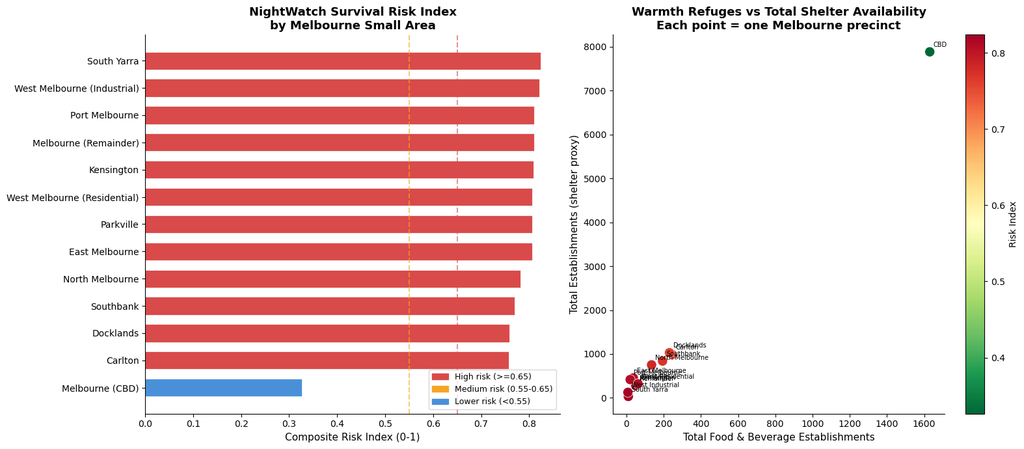

```
Figure saved: nightwatch_risk_surface.png
```

```python
risk_sorted = clue_risk.sort_values('risk_index', ascending=True)

tier_colours = {'HIGH': '#D94A4A', 'MEDIUM': '#F5A623', 'LOW': '#4A90D9'}
colours = risk_sorted['risk_tier'].map(tier_colours)

fig, axes = plt.subplots(1, 2, figsize=(16, 7))

# Left: ranked risk index bar chart
axes[0].barh(
    risk_sorted['clue_small_area'],
    risk_sorted['risk_index'],
    color=colours, edgecolor='white', linewidth=0.5, height=0.65
)
axes[0].axvline(x=0.65, color='#D94A4A', linestyle='--', alpha=0.6, linewidth=1.5, label='High risk threshold')
axes[0].axvline(x=0.55, color='#F5A623', linestyle='--', alpha=0.6, linewidth=1.5, label='Medium risk threshold')
axes[0].set_title(
    'NightWatch Survival Risk Index\nby Melbourne Small Area',
    fontsize=13, fontweight='bold'
)
axes[0].set_xlabel('Composite Risk Index (0-1)', fontsize=11)
high_p   = mpatches.Patch(color='#D94A4A', label='High risk (>=0.65)')
med_p    = mpatches.Patch(color='#F5A623', label='Medium risk (0.55-0.65)')
low_p    = mpatches.Patch(color='#4A90D9', label='Lower risk (<0.55)')
axes[0].legend(handles=[high_p, med_p, low_p], fontsize=9, loc='lower right')
axes[0].spines['top'].set_visible(False)
axes[0].spines['right'].set_visible(False)

# Right: warmth refuge vs shelter scatter coloured by risk
scatter = axes[1].scatter(
    clue_risk['total_food_bev'],
    clue_risk['total_establishments'],
    c=clue_risk['risk_index'],
    cmap='RdYlGn_r',
    s=120, edgecolors='white', linewidth=0.5, zorder=3
)
plt.colorbar(scatter, ax=axes[1], label='Risk Index')

# Label each point
for _, row in clue_risk.iterrows():
    axes[1].annotate(
        row['clue_small_area'].replace('Melbourne (', '').replace(')', ''),
        (row['total_food_bev'], row['total_establishments']),
        fontsize=7, ha='left', va='bottom',
        xytext=(4, 4), textcoords='offset points'
    )

axes[1].set_title(
    'Warmth Refuges vs Total Shelter Availability\nEach point = one Melbourne precinct',
    fontsize=13, fontweight='bold'
)
axes[1].set_xlabel('Total Food & Beverage Establishments', fontsize=11)
axes[1].set_ylabel('Total Establishments (shelter proxy)', fontsize=11)
axes[1].spines['top'].set_visible(False)
axes[1].spines['right'].set_visible(False)

plt.tight_layout()
plt.savefig('nightwatch_risk_surface.png', dpi=150, bbox_inches='tight')
plt.show()
print("Figure saved: nightwatch_risk_surface.png")
```

### 8.6 Output Analysis - Visualisation 5: Risk Surface

The left chart confirms the CBD's outlier status - it is the only precinct below both risk thresholds, sitting at 0.32. All 12 other precincts clear the HIGH threshold of 0.65 with scores between 0.76 and 0.82.

The right scatter plot tells the clearest story. The CBD sits isolated in the top right corner - 1,630 food and beverage establishments and 7,883 total establishments - coloured green for low risk. Every other precinct clusters tightly in the bottom left with under 250 food and beverage establishments and under 1,100 total establishments. The gap between the CBD and the rest of Melbourne is not gradual - it is a structural discontinuity.

This validates the central premise of NightWatch: the City of Melbourne's warmth and shelter infrastructure is highly concentrated in the CBD, leaving all surrounding precincts significantly more exposed for rough sleepers who cannot or do not access the CBD overnight.

### 8.7 - Final Output: Priority Precincts for Welfare Checks

```python
# Final ranked welfare check output

final_output = clue_risk[[
    'clue_small_area', 'total_food_bev', 'total_establishments',
    'block_count', 'warmth_refuge_score', 'shelter_score',
    'risk_index', 'risk_tier'
]].sort_values('risk_index', ascending=False).reset_index(drop=True)
final_output.index += 1

print("=" * 70)
print("  NIGHTWATCH - PRIORITY PRECINCTS FOR WELFARE CHECKS")
print("  Ranked by composite survival risk index")
print("=" * 70)
print(final_output.to_string())

print(f"\n  Risk tier distribution:")
print(final_output['risk_tier'].value_counts().to_string())

print(f"\n  Interpretation:")
high = final_output[final_output['risk_tier'] == 'HIGH']
med  = final_output[final_output['risk_tier'] == 'MEDIUM']
print(f"  HIGH priority precincts   : {len(high)}")
print(f"  MEDIUM priority precincts : {len(med)}")
if len(high) > 0:
    print(f"\n  Highest risk precinct: {high.iloc[0]['clue_small_area']}")
    print(f"  Risk index           : {high.iloc[0]['risk_index']:.4f}")
    print(f"  Food & bev count     : {high.iloc[0]['total_food_bev']}")
```

```
======================================================================
  NIGHTWATCH - PRIORITY PRECINCTS FOR WELFARE CHECKS
  Ranked by composite survival risk index
======================================================================
                 clue_small_area  total_food_bev  total_establishments  block_count  warmth_refuge_score  shelter_score  risk_index risk_tier
1                    South Yarra              10                    33            3                 0.99           1.00        0.82      HIGH
2    West Melbourne (Industrial)               8                   127            8                 1.00           0.98        0.82      HIGH
3                 Port Melbourne              20                   417           10                 0.99           0.95        0.81      HIGH
4          Melbourne (Remainder)              50                   282           12                 0.97           0.96        0.81      HIGH
5                     Kensington              56                   291           21                 0.97           0.96        0.81      HIGH
6   West Melbourne (Residential)              62                   321           24                 0.96           0.96        0.81      HIGH
7                      Parkville              64                   322           14                 0.96           0.96        0.81      HIGH
8                 East Melbourne              37                   456           19                 0.98           0.94        0.81      HIGH
9                North Melbourne             135                   753           52                 0.92           0.90        0.78      HIGH
10                     Southbank             194                   840           32                 0.88           0.89        0.77      HIGH
11                     Docklands             231                  1030           13                 0.86           0.87        0.76      HIGH
12                       Carlton             246                   988           48                 0.85           0.87        0.76      HIGH
13               Melbourne (CBD)            1630                  7883           81                 0.00           0.00        0.33       LOW

  Risk tier distribution:
risk_tier
HIGH    12
LOW      1

  Interpretation:
  HIGH priority precincts   : 12
  MEDIUM priority precincts : 0

  Highest risk precinct: South Yarra
  Risk index           : 0.8238
  Food & bev count     : 10
```

## Section 9: Conclusion and Future Work

### Key Findings

NightWatch successfully identified **12 HIGH priority precincts** and **1 LOW priority precinct** across the City of Melbourne using a composite survival risk index built entirely from open data.

### Methodology Summary

Four proxy variables were engineered from City of Melbourne Open Data:

[output not shown]

Each variable was normalised to 0–1 and equally weighted at 0.25 to produce the final composite risk index.

### Limitations

- **Sensor coverage is CBD-centric.** Pedestrian and microclimate sensors are concentrated in the inner city - outer precincts receive averaged scores rather than location-specific measurements.
- **Static snapshot.** The current model uses aggregated historical data rather than real-time feeds. A live version would require streaming API access.
- **Equal weighting assumption.** The 0.25 equal weighting across all four proxies is a starting point. Domain consultation with outreach workers could inform a more evidence-based weighting.
- **No direct rough sleeper data.** NightWatch uses environmental proxies - it identifies where conditions are most dangerous, not where rough sleepers are actually located.

### Future Work

- Integrate real-time microclimate data for live overnight risk alerts
- Add spatial mapping with folium to visualise the risk surface on an interactive map
- Consult with welfare outreach teams to validate and refine the proxy weightings
- Expand to include additional datasets such as public lighting, CCTV coverage, and hospital proximity
- Build an automated nightly report that ranks precincts by current conditions and sends alerts to outreach coordinators